# Stacked Spatial Weight Tutorial

Marynia Kolak

November 8, 2017

```r
library(splm)
library(spdep)
library(rgdal)
library(spdep)
library(maptools)
library(foreign)
```

## Data Preparation

Open the shapefile of Counties that we need to create a stacked weight for in R.

```r
Counties<- readOGR(".","USCounties")
```

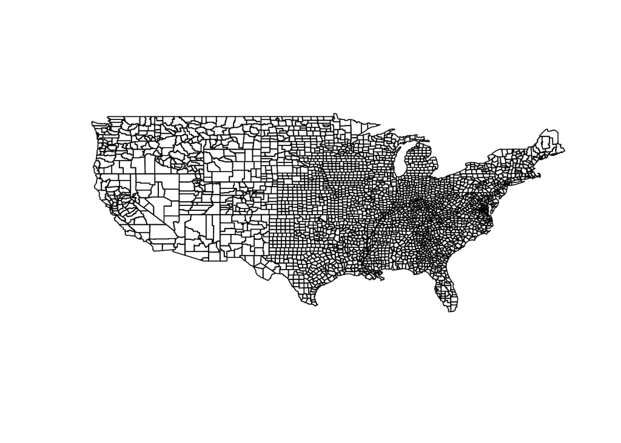

```r
# Plot polygons for inspection
plot(Counties)
```

First, check how many counties are in the datases. This is good practice to ensure you are getting all the data you were expecting.

```r
length(Counties)
```

```
## [1] 3098
```

Next, we’ll need to work with the unique identifier for each county. If the data structure for the unique FIPS code is a factor, we’ll need to convert to numeric value. Once converted, we look at the first few records of our dataset to ensure we have all the data required before continuing. Because this is a spatial format, we look at the data attached only by using @data.

```r
class(Counties$FIPS)
```

```
## [1] "factor"
```

```r
Counties$RID <- as.numeric(Counties$FIPS)
head(Counties@data)
```

```
##        AREA PERIMETER CO99_D00_ CO99_D00_I STATE COUNTY              NAME
## 0 0.5623933  4.254051       115        114    27    077 Lake of the Woods
## 1 0.6839444  5.326881       116        115    53    073           Whatcom
## 2 1.6499787  8.658548       118        117    30    029          Flathead
## 3 1.1592117  5.614212       119        118    30    053           Lincoln
## 4 0.4048582  2.966526       120        119    16    021          Boundary
## 5 1.3342615  5.517993       121        120    30    005            Blaine
##   LSAD LSAD_TRANS  FIPS OID_ FIPS_1 PR_END0105 PS_END0609  PR_ANNUAL
## 0   06     County 27077 1315  27077  0.3895349  0.1918159 0.07790698
## 1   06     County 53073 2945  53073  0.4103035  0.3763109 0.08206070
## 2   06     County 30029 1575  30029  0.4277601  0.3227757 0.08555203
## 3   06     County 30053 1587  30053  0.3678284  0.3022063 0.07356568
## 4   06     County 16021  525  16021  0.2394958  0.2063291 0.04789916
## 5   06     County 30005 1563  30005  0.3296178  0.3384615 0.06592357
##    PS_ANNUAL PR_AGE1   PS_AGE1 PR_AGE2   PS_AGE2 PR_AGE3    PS_AGE3 PR_FEM
```

[output cut: 48 more lines]

Here we create an index that is the length of the total number of counties we have. (Or more precisely, that is the length of all unique identifiers, which should be the same.) Check the length of the index to confirm it matches the total number of counties.

```r
index<- seq.int(length(Counties$RID))
length(index)
```

```
## [1] 3098
```

# Create big W matrix for panel analysis

First, generate a weight. Here we use the [nb](https://cran.r-project.org/web/packages/spdep/vignettes/nb.pdf) package to create a first-order queen contiguity weight for each county.

```r
W_q1 <- poly2nb(Counties,queen=TRUE)
```

Check the length of the weight. This should equal the length of one time period, or the total rows of Counties we start with.

```r
length(W_q1)
```

```
## [1] 3098
```

Convert the weight to a weight-list object.

```r
wr<- nb2listw(W_q1)
```

Convert to a sparse matrix.

```r
w1<- listw2dgCMatrix(wr)
```

Create time periods, and validate. Because we have two time periods here, the length should be twice the size of our original dataset.

```r
time_id<- c("PR","PS")
tperiods <- length(time_id)
tperiods
```

```
## [1] 2
```

Calculate the Kronecker product using a sparse matrix with diagonal = tperiods.

```r
I.T <- Diagonal(tperiods)
I.T
```

```
## 2 x 2 diagonal matrix of class "ddiMatrix"
##      [,1] [,2]
## [1,]    1    .
## [2,]    .    1
```

```r
bigWmat <- kronecker(I.T,w1)
str(bigWmat)
```

```
## Formal class 'dgTMatrix' [package "Matrix"] with 6 slots
##   ..@ i       : int [1:36244] 16 30 42 7 31 3 26 43 49 60 ...
##   ..@ j       : int [1:36244] 0 0 0 1 1 2 2 2 2 2 ...
##   ..@ Dim     : int [1:2] 6196 6196
##   ..@ Dimnames:List of 2
##   .. ..$ : NULL
##   .. ..$ : NULL
##   ..@ x       : num [1:36244] 0.25 0.25 0.111 0.143 0.25 ...
##   ..@ factors : list()
```

Inspect the big Weights matrix produced. It should be 3098 counties x 2 time periods = 6196 wide and long.

```r
head(bigWmat)
```

```
## 6 x 6196 sparse Matrix of class "dgTMatrix"
##
## [1,] . . .    .         .    . . .   . . .    . . .         .    .
## [2,] . . .    .         .    . . 0.5 . . .    . . .         .    .
## [3,] . . .    0.1111111 .    . . .   . . .    . . .         .    .
## [4,] . . 0.25 .         0.25 . . .   . . .    . . .         .    .
## [5,] . . .    0.3333333 .    . . .   . . .    . . 0.3333333 .    .
## [6,] . . .    .         .    . . .   . . 0.25 . . .         0.25 .
##
## [1,] 0.3333333 . . . . . . . . . .         . .         . 0.3333333 ......
## [2,] .         . . . . . . . . . .         . .         . .         ......
## [3,] .         . . . . . . . . . 0.1111111 . .         . .         ......
## [4,] .         . . . . . . . . . .         . 0.2500000 . .         ......
## [5,] .         . . . . . . . . . .         . 0.3333333 . .         ......
## [6,] .         . . . . . . . . . .         . .         . .         ......
##
##  .....suppressing columns in show(); maybe adjust 'options(max.print= *, width = *)'
##  ..............................
```

Convert back to list weights object.

```r
bigW <- mat2listw(bigWmat,style="W")
summary(bigW)
```

```
## Characteristics of weights list object:
## Neighbour list object:
## Number of regions: 6196
## Number of nonzero links: 36244
## Percentage nonzero weights: 0.09440898
## Average number of links: 5.84958
## Link number distribution:
##
##    1    2    3    4    5    6    7    8    9   10   11   13   14
##   42   82  180  564 1318 2136 1322  430   96   18    4    2    2
## 42 least connected regions:
## 45 49 51 99 282 827 855 938 1388 1484 1565 1595 1631 1655 1662 1723 1730 1786 1932 1968 1969 3143 3147 3149 3197 3380 3925 3953 4036 4486 4582 4663 4693 4729 4753 4760 4821 4828 4884 5030 5066 5067 with 1 link
## 2 most connected regions:
## 1563 4661 with 14 links
##
## Weights style: W
## Weights constants summary:
##      n       nn   S0       S1       S2
## W 6196 38390416 6196 2227.779 25236.31
```

```r
class(bigW)
```

```
## [1] "listw" "nb"
```

The stacked weight is ready for writing. Write to a .gal file for use in GeodaSpace.

```r
write.nb.gal(bigW$n, "Counties_BigW.gal", oldstyle=FALSE)
```